# Capstone

```python
import pandas as pd
import numpy as np
import matplotlib.pyplot as plt
import seaborn as sns
%matplotlib inline
import statsmodels.api as sm
from sklearn.model_selection import train_test_split
from sklearn.preprocessing import StandardScaler, LabelEncoder
from sklearn.linear_model import LogisticRegression
from sklearn.metrics import accuracy_score, classification_report, confusion_matrix
from scipy import stats
```

### Library Imports and Analysis Environment

This analysis was completed in a Python-based Jupyter Notebook using libraries that support data preparation, visualization, modeling, and evaluation.

pandas and NumPy were used for data loading, cleaning, and numerical operations. Matplotlib and Seaborn supported exploratory data analysis and visualization. scikit-learn provided tools for preprocessing, model development, and performance evaluation, while statsmodels was used for multinomial logistic regression and statistical inference.

The `%matplotlib inline` setting ensures that all figures are displayed directly within the notebook, supporting a clear and reproducible workflow.

```python
df = pd.read_csv('spotify_tracks_genre.csv')
```

### Loading the Dataset

The Spotify music dataset was loaded into the analysis environment using the `read_csv()` function from the pandas library. This step converts the raw CSV file into a pandas DataFrame, allowing the data to be easily inspected, cleaned, and analyzed using Python.

```python
df.head()
```

|  | Unnamed: 0 | track_id | artists | album_name | track_name | popularity | duration_ms | explicit | danceability | energy | ... | loudness | mode | speechiness | acousticness | instrumentalness | liveness | valence | tempo | time_signature | track_genre |
| --- | --- | --- | --- | --- | --- | --- | --- | --- | --- | --- | --- | --- | --- | --- | --- | --- | --- | --- | --- | --- | --- |
| 0 | 0 | 5SuOikwiRyPMVoIQDJUgSV | Gen Hoshino | Comedy | Comedy | 73 | 230666 | False | 0.676 | 0.4610 | ... | -6.746 | 0 | 0.1430 | 0.0322 | 0.000001 | 0.3580 | 0.715 | 87.917 | 4 | acoustic |
| 1 | 1 | 4qPNDBW1i3p13qLCt0Ki3A | Ben Woodward | Ghost (Acoustic) | Ghost - Acoustic | 55 | 149610 | False | 0.420 | 0.1660 | ... | -17.235 | 1 | 0.0763 | 0.9240 | 0.000006 | 0.1010 | 0.267 | 77.489 | 4 | acoustic |
| 2 | 2 | 1iJBSr7s7jYXzM8EGcbK5b | Ingrid Michaelson;ZAYN | To Begin Again | To Begin Again | 57 | 210826 | False | 0.438 | 0.3590 | ... | -9.734 | 1 | 0.0557 | 0.2100 | 0.000000 | 0.1170 | 0.120 | 76.332 | 4 | acoustic |
| 3 | 3 | 6lfxq3CG4xtTiEg7opyCyx | Kina Grannis | Crazy Rich Asians (Original Motion Picture Sou... | Can't Help Falling In Love | 71 | 201933 | False | 0.266 | 0.0596 | ... | -18.515 | 1 | 0.0363 | 0.9050 | 0.000071 | 0.1320 | 0.143 | 181.740 | 3 | acoustic |
| 4 | 4 | 5vjLSffimiIP26QG5WcN2K | Chord Overstreet | Hold On | Hold On | 82 | 198853 | False | 0.618 | 0.4430 | ... | -9.681 | 1 | 0.0526 | 0.4690 | 0.000000 | 0.0829 | 0.167 | 119.949 | 4 | acoustic |

5 rows × 21 columns

### Previewing the Dataset

To confirm that the dataset loaded correctly and to get an initial sense of its structure, the first five rows of the DataFrame were displayed using `head()`. This preview provides a quick look at the available columns, including track metadata, genre labels, and Spotify audio features.

Reviewing a small sample of the data at this stage helps verify that the expected variables are present and that the values appear reasonable before moving on to further inspection and preparation.

```python
df.info()
```

```
<class 'pandas.core.frame.DataFrame'>
RangeIndex: 114000 entries, 0 to 113999
Data columns (total 21 columns):
 #   Column            Non-Null Count   Dtype
---  ------            --------------   -----
 0   Unnamed: 0        114000 non-null  int64
 1   track_id          114000 non-null  object
 2   artists           113999 non-null  object
 3   album_name        113999 non-null  object
 4   track_name        113999 non-null  object
 5   popularity        114000 non-null  int64
 6   duration_ms       114000 non-null  int64
 7   explicit          114000 non-null  bool
 8   danceability      114000 non-null  float64
 9   energy            114000 non-null  float64
 10  key               114000 non-null  int64
 11  loudness          114000 non-null  float64
 12  mode              114000 non-null  int64
 13  speechiness       114000 non-null  float64
 14  acousticness      114000 non-null  float64
 15  instrumentalness  114000 non-null  float64
 16  liveness          114000 non-null  float64
 17  valence           114000 non-null  float64
 18  tempo             114000 non-null  float64
 19  time_signature    114000 non-null  int64
 20  track_genre       114000 non-null  object
dtypes: bool(1), float64(9), int64(6), object(5)
memory usage: 17.5+ MB
```

### Dataset Structure and Data Type Verification

The `df.info()` output was used to examine the overall structure, size, and data types of the dataset prior to data preparation and modeling. The dataset contains 114,000 observations and 21 variables, confirming that the data loaded successfully and matches the expected dimensions.

Most columns are fully populated, with only a small number of missing values in select metadata fields such as artist and track name. Because the audio features and genre labels contain no missing values, no imputation was required for the variables used in modeling.

The data types are appropriately assigned, with continuous audio features stored as numeric values and categorical identifiers stored as objects. Verifying the dataset structure at this stage ensured that the data were suitable for subsequent filtering, feature selection, and model development.

```python
df.shape
```

```
(114000, 21)
```

### Dataset Dimensions

The `df.shape` output confirms that the dataset contains 114,000 rows and 21 columns. Each row represents an individual Spotify track, and the columns include track metadata, Spotify audio features, and the genre label used for classification.

Confirming the dataset dimensions at this stage ensured that the data were fully loaded and appropriate for subsequent filtering and analysis.

```python
print(df.describe())
```

```
          Unnamed: 0     popularity   duration_ms   danceability  \
count  114000.000000  114000.000000  1.140000e+05  114000.000000
mean    56999.500000      33.238535  2.280292e+05       0.566800
std     32909.109681      22.305078  1.072977e+05       0.173542
min         0.000000       0.000000  0.000000e+00       0.000000
25%     28499.750000      17.000000  1.740660e+05       0.456000
50%     56999.500000      35.000000  2.129060e+05       0.580000
75%     85499.250000      50.000000  2.615060e+05       0.695000
max    113999.000000     100.000000  5.237295e+06       0.985000

              energy            key       loudness           mode  \
count  114000.000000  114000.000000  114000.000000  114000.000000
mean        0.641383       5.309140      -8.258960       0.637553
std         0.251529       3.559987       5.029337       0.480709
min         0.000000       0.000000     -49.531000       0.000000
25%         0.472000       2.000000     -10.013000       0.000000
50%         0.685000       5.000000      -7.004000       1.000000
75%         0.854000       8.000000      -5.003000       1.000000
max         1.000000      11.000000       4.532000       1.000000

         speechiness   acousticness  instrumentalness       liveness  \
count  114000.000000  114000.000000     114000.000000  114000.000000
mean        0.084652       0.314910          0.156050       0.213553
std         0.105732       0.332523          0.309555       0.190378
min         0.000000       0.000000          0.000000       0.000000
25%         0.035900       0.016900          0.000000       0.098000
50%         0.048900       0.169000          0.000042       0.132000
75%         0.084500       0.598000          0.049000       0.273000
max         0.965000       0.996000          1.000000       1.000000

             valence          tempo  time_signature
count  114000.000000  114000.000000   114000.000000
mean        0.474068     122.147837        3.904035
std         0.259261      29.978197        0.432621
min         0.000000       0.000000        0.000000
25%         0.260000      99.218750        4.000000
50%         0.464000     122.017000        4.000000
75%         0.683000     140.071000        4.000000
max         0.995000     243.372000        5.000000
```

### Descriptive Statistics for Numeric Variables

Descriptive statistics were generated using `df.describe()` to summarize the distribution of the numeric variables in the dataset. This output provides key information on central tendency, spread, and range for each feature.

Several audio features, such as instrumentalness and speechiness, show low median values and right-skewed distributions, which is common in music data. Other variables, including tempo, loudness, and energy, exhibit wider ranges and greater variability.

Reviewing these distributions confirmed that the audio features fall within expected ranges and informed the decision to apply feature scaling prior to model training so that no single variable would dominate the classification results.

```python
audio_features = [
    'tempo',
    'energy',
    'loudness',
    'danceability',
    'speechiness',
    'instrumentalness',
    'liveness',
    'valence',
    'acousticness']
df[audio_features].describe()
```

|  | tempo | energy | loudness | danceability | speechiness | instrumentalness | liveness | valence | acousticness |
| --- | --- | --- | --- | --- | --- | --- | --- | --- | --- |
| count | 114000.000000 | 114000.000000 | 114000.000000 | 114000.000000 | 114000.000000 | 114000.000000 | 114000.000000 | 114000.000000 | 114000.000000 |
| mean | 122.147837 | 0.641383 | -8.258960 | 0.566800 | 0.084652 | 0.156050 | 0.213553 | 0.474068 | 0.314910 |
| std | 29.978197 | 0.251529 | 5.029337 | 0.173542 | 0.105732 | 0.309555 | 0.190378 | 0.259261 | 0.332523 |
| min | 0.000000 | 0.000000 | -49.531000 | 0.000000 | 0.000000 | 0.000000 | 0.000000 | 0.000000 | 0.000000 |
| 25% | 99.218750 | 0.472000 | -10.013000 | 0.456000 | 0.035900 | 0.000000 | 0.098000 | 0.260000 | 0.016900 |
| 50% | 122.017000 | 0.685000 | -7.004000 | 0.580000 | 0.048900 | 0.000042 | 0.132000 | 0.464000 | 0.169000 |
| 75% | 140.071000 | 0.854000 | -5.003000 | 0.695000 | 0.084500 | 0.049000 | 0.273000 | 0.683000 | 0.598000 |
| max | 243.372000 | 1.000000 | 4.532000 | 0.985000 | 0.965000 | 1.000000 | 1.000000 | 0.995000 | 0.996000 |

### Descriptive Statistics for Selected Audio Features

Descriptive statistics were calculated for the nine Spotify audio features used as predictors in the model. This summary highlights differences in scale, variability, and distribution across features prior to modeling.

Features such as speechiness and instrumentalness show low median values and right-skewed distributions, which is typical for music audio data. In contrast, variables like tempo, loudness, and energy exhibit wider ranges and greater variability across tracks.

These differences in scale reinforced the need for feature standardization before fitting the logistic regression model to ensure that no single feature disproportionately influenced the results.

```python
df['track_genre'].value_counts()
```

```
track_genre
acoustic             1000
punk-rock            1000
progressive-house    1000
power-pop            1000
pop                  1000
                     ...
folk                 1000
emo                  1000
electronic           1000
electro              1000
world-music          1000
Name: count, Length: 114, dtype: int64
```

### Review of Genre Distribution in the Full Dataset

The genre distribution was examined using `value_counts()` to assess class balance prior to filtering the dataset. The results show that all 114 genres are evenly represented, with exactly 1,000 tracks per genre.

Confirming this uniform distribution ensured that no genre was overrepresented in the original dataset and supported fair model training, evaluation, and comparison across genres.

```python
all_genres = sorted(df['track_genre'].unique().tolist())
print(all_genres)
```

[output not shown]

### Exploring the Full Set of Music Genres

All unique music genres in the dataset were identified by extracting and sorting the distinct values from the `track_genre` column. This step provided an overview of the genre diversity available for analysis.

The dataset contains 114 unique genres, ranging from widely recognized categories such as pop, rock, and jazz to more specialized and region-specific styles. Reviewing the full genre list helped inform the decision to narrow the analysis to a smaller subset of well-known genres, balancing model interpretability with musical diversity.

```python
top_20_genres = [
    'alternative',
    'blues',
    'classical',
    'country',
    'death-metal',
    'disco',
    'dubstep',
    'gospel',
    'hip-hop',
    'industrial',
    'jazz',
    'opera',
    'pop',
    'punk-rock',
    'reggae',
    'rock',
    'soul',
    'hardcore',
    'grunge',
    'folk']
```

### Selecting the Top 20 Genres for Analysis

To keep the analysis focused and interpretable, a subset of 20 music genres was selected from the full list of 114 genres. These genres were chosen to represent a broad range of musical styles, including mainstream, acoustic, electronic, and rock-based categories.

Limiting the analysis to 20 genres balances model complexity with interpretability. This approach reduces computational burden while still allowing meaningful comparison between genres with both distinctive and overlapping audio characteristics, making the results more practical and easier to interpret.

```python
df_20 = df[df['track_genre'].isin(top_20_genres)].copy()
```

### Filtering the Dataset to the Selected Top 20 Genres

The dataset was filtered to retain only tracks belonging to the selected 20 genres, creating a focused analysis dataset (`df_20`). This ensured that all subsequent preparation and modeling steps were applied consistently to the same subset of data.

Narrowing the dataset at this stage reduced model complexity and improved interpretability while maintaining practical relevance for music streaming applications. A copy of the filtered dataset was created to preserve the integrity of the original data and support reproducibility.

```python
df_20.head()
```

|  | Unnamed: 0 | track_id | artists | album_name | track_name | popularity | duration_ms | explicit | danceability | energy | ... | loudness | mode | speechiness | acousticness | instrumentalness | liveness | valence | tempo | time_signature | track_genre |
| --- | --- | --- | --- | --- | --- | --- | --- | --- | --- | --- | --- | --- | --- | --- | --- | --- | --- | --- | --- | --- | --- |
| 3000 | 3000 | 5E30LdtzQTGqRvNd7l6kG5 | The Neighbourhood | Wiped Out! | Daddy Issues | 87 | 260173 | False | 0.588 | 0.521 | ... | -9.461 | 1 | 0.0329 | 0.0678 | 0.149000 | 0.123 | 0.337 | 85.012 | 4 | alternative |
| 3001 | 3001 | 09gysnJpfQ3ublBmJDfcEC | Amaarae;Kali Uchis;Moliy | SAD GIRLZ LUV MONEY Remix (feat. Kali Uchis an... | SAD GIRLZ LUV MONEY Remix (feat. Kali Uchis an... | 79 | 204763 | True | 0.870 | 0.523 | ... | -8.052 | 0 | 0.0602 | 0.4330 | 0.000021 | 0.113 | 0.319 | 110.020 | 4 | alternative |
| 3002 | 3002 | 2K7xn816oNHJZ0aVqdQsha | The Neighbourhood | Hard To Imagine The Neighbourhood Ever Changing | Softcore | 86 | 206280 | False | 0.575 | 0.568 | ... | -5.509 | 0 | 0.0300 | 0.0484 | 0.000417 | 0.286 | 0.370 | 93.986 | 4 | alternative |
| 3003 | 3003 | 2QjOHCTQ1Jl3zawyYOpxh6 | The Neighbourhood | I Love You. | Sweater Weather | 93 | 240400 | False | 0.612 | 0.807 | ... | -2.810 | 1 | 0.0336 | 0.0495 | 0.017700 | 0.101 | 0.398 | 124.053 | 4 | alternative |
| 3004 | 3004 | 4fouWK6XVHhzl78KzQ1UjL | GAYLE | abcdefu | abcdefu | 86 | 168601 | True | 0.695 | 0.540 | ... | -5.692 | 1 | 0.0493 | 0.2990 | 0.000000 | 0.367 | 0.415 | 121.932 | 4 | alternative |

5 rows × 21 columns

### Preview of the Filtered Dataset (Top 20 Genres)

The first few rows of the filtered dataset were displayed using `df_20.head()` to confirm that the genre filtering was applied correctly. This preview shows that only tracks from the selected 20 genres are included and that all original variables were preserved.

Reviewing the filtered dataset at this stage provided a quick validation check before moving on to class balance verification, feature scaling, and model training.

```python
df_20['track_genre'].value_counts()
```

```
track_genre
alternative    1000
blues          1000
rock           1000
reggae         1000
punk-rock      1000
pop            1000
opera          1000
jazz           1000
industrial     1000
hip-hop        1000
hardcore       1000
grunge         1000
gospel         1000
folk           1000
dubstep        1000
disco          1000
death-metal    1000
country        1000
classical      1000
soul           1000
Name: count, dtype: int64
```

### Verification of Class Balance for the Selected Genres

After filtering the dataset to the selected 20 genres, genre frequencies were reviewed using `value_counts()` to confirm class balance. Each genre contains exactly 1,000 tracks, resulting in a balanced dataset with 20,000 total observations.

Verifying class balance at this stage helps prevent bias during model training and supports fair evaluation and comparison of classification performance across genres.

```python
missing_summary = df_20.isnull().sum()
missing_summary[missing_summary > 0]
```

```
Series([], dtype: int64)
```

### Missing Value Assessment

The filtered dataset was checked for missing values using `isnull().sum()`. The results show that no missing values are present in any of the selected variables.

Because the dataset is complete, no imputation or row removal was required before proceeding with feature scaling and model training.

```python
df_20.to_csv("prepared_top_20.csv",index=False)
```

### Saving the Prepared Dataset

The filtered dataset was saved as a separate CSV file to preserve a clean, untransformed version of the analysis data. This step creates a clear checkpoint in the data preparation process.

Saving the dataset at this stage supports reproducibility and allows later preprocessing steps, such as feature scaling and model training, to be replicated or reviewed independently.

```python
df_20.info()
```

```
<class 'pandas.core.frame.DataFrame'>
Index: 20000 entries, 3000 to 103999
Data columns (total 21 columns):
 #   Column            Non-Null Count  Dtype
---  ------            --------------  -----
 0   Unnamed: 0        20000 non-null  int64
 1   track_id          20000 non-null  object
 2   artists           20000 non-null  object
 3   album_name        20000 non-null  object
 4   track_name        20000 non-null  object
 5   popularity        20000 non-null  int64
 6   duration_ms       20000 non-null  int64
 7   explicit          20000 non-null  bool
 8   danceability      20000 non-null  float64
 9   energy            20000 non-null  float64
 10  key               20000 non-null  int64
 11  loudness          20000 non-null  float64
 12  mode              20000 non-null  int64
 13  speechiness       20000 non-null  float64
 14  acousticness      20000 non-null  float64
 15  instrumentalness  20000 non-null  float64
 16  liveness          20000 non-null  float64
 17  valence           20000 non-null  float64
 18  tempo             20000 non-null  float64
 19  time_signature    20000 non-null  int64
 20  track_genre       20000 non-null  object
dtypes: bool(1), float64(9), int64(6), object(5)
memory usage: 3.2+ MB
```

### Dataset Structure and Data Type Verification (Filtered Dataset)

The structure of the filtered dataset was reviewed using `df_20.info()`. The output confirms that the dataset contains 20,000 observations across 21 variables, with no missing values in any column.

All variables are appropriately typed, including numeric audio features, integer-based metadata, boolean indicators, and categorical genre labels. This verification confirms that the filtered dataset is complete and ready for feature scaling and multinomial logistic regression modeling.

```python
audio_features = [
    'tempo',
    'energy',
    'loudness',
    'danceability',
    'speechiness',
    'instrumentalness',
    'liveness',
    'valence',
    'acousticness']
```

### Selection of Audio Feature Variables

The analysis focuses on nine Spotify audio features that capture key musical characteristics related to rhythm, intensity, mood, and acoustic structure. These features are commonly used in music analytics and are well suited for distinguishing between genres.

Limiting the model to these continuous audio features improves interpretability and reduces model complexity while ensuring that all predictors are measured on comparable numeric scales appropriate for regression-based classification.

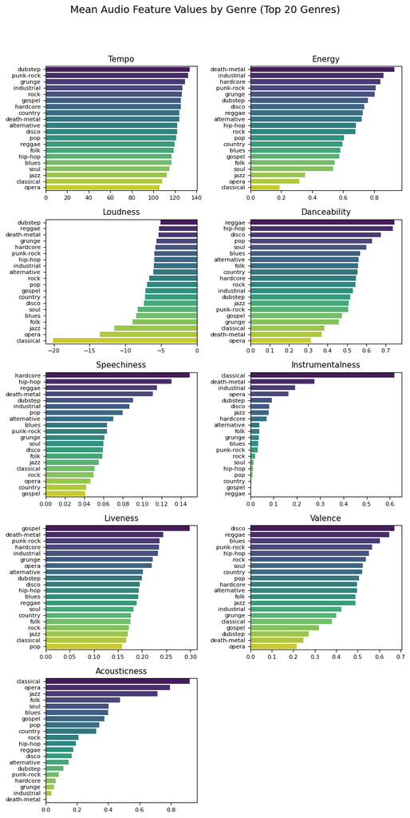

```python
fig, axes = plt.subplots(5, 2, figsize=(8, 16))
axes = axes.flatten()
for i, feature in enumerate(audio_features):
    feature_means = (
        df_20.groupby("track_genre")[feature]
        .mean()
        .sort_values(ascending=False)
        .reset_index())
    sns.barplot(
        data=feature_means,
        y="track_genre",
        x=feature,
        ax=axes[i],
        hue="track_genre",
        dodge=False,
        legend=False,
        palette="viridis")
    axes[i].set_title(feature.capitalize(), fontsize=11)
    axes[i].set_xlabel("")
    axes[i].set_ylabel("")
    axes[i].tick_params(axis="y", labelsize=8)
    axes[i].tick_params(axis="x", labelsize=8)
for j in range(len(audio_features), len(axes)):
    fig.delaxes(axes[j])
plt.suptitle(
    "Mean Audio Feature Values by Genre (Top 20 Genres)",
    fontsize=14)
plt.tight_layout(rect=[0, 0, 1, 0.95])
plt.show()
```

### Mean Audio Feature Values by Genre (Top 20 Genres)

The charts above show the average values of key Spotify audio features for each of the selected 20 genres. Visualizing feature means by genre helps highlight patterns and differences in musical characteristics across genres.

Clear distinctions emerge for several features. For example, death metal, hardcore, and industrial genres show high average energy and loudness, while classical and opera stand out with high instrumentalness and acousticness. Genres such as hip-hop and reggae exhibit higher speechiness, reflecting greater vocal and spoken-word content, while disco and pop show higher danceability and valence.

These visual patterns support the use of audio features for genre classification and provide intuitive context for the statistical modeling that follows. They also help explain why certain genres are easier to distinguish than others based on their underlying audio characteristics.

```python
X = df_20[audio_features].copy()
y = df_20["track_genre"].copy()
print("X shape:", X.shape)
print("y distribution:\n", y.value_counts())
```

```
X shape: (20000, 9)
y distribution:
 track_genre
alternative    1000
blues          1000
rock           1000
reggae         1000
punk-rock      1000
pop            1000
opera          1000
jazz           1000
industrial     1000
hip-hop        1000
hardcore       1000
grunge         1000
gospel         1000
folk           1000
dubstep        1000
disco          1000
death-metal    1000
country        1000
classical      1000
soul           1000
Name: count, dtype: int64
```

### Feature Matrix and Target Variable Definition

The dataset was split into predictor variables (X) and a target variable (y) in preparation for model training. The feature matrix consists of nine Spotify audio features, while the target variable represents the music genre (`track_genre`).

The feature matrix contains 20,000 observations and 9 predictors, and the target variable is evenly distributed, with 1,000 tracks per genre across all 20 classes. This balanced structure supports fair model training and evaluation and reduces the risk of bias toward any single genre.

```python
le = LabelEncoder()
y_encoded = le.fit_transform(y)
print("Number of genres:", len(le.classes_))
print("Genres:", le.classes_)
```

```
Number of genres: 20
Genres: ['alternative' 'blues' 'classical' 'country' 'death-metal' 'disco'
 'dubstep' 'folk' 'gospel' 'grunge' 'hardcore' 'hip-hop' 'industrial'
 'jazz' 'opera' 'pop' 'punk-rock' 'reggae' 'rock' 'soul']
```

### Encoding of Genre Labels

Because logistic regression requires numeric target values, the categorical genre labels were encoded using a label encoder. This step converts each genre into a unique numeric value while preserving the original class structure.

The output confirms that all 20 selected genres were successfully encoded and that no classes were lost or merged during the process. This ensures the target variable is in the correct format for model training.

```python
X_train, X_test, y_train, y_test = train_test_split(
    X,
    y_encoded,
    test_size=0.20,
    random_state=42,
    stratify=y_encoded)
print("Train:", X_train.shape, "Test:", X_test.shape)
```

```
Train: (16000, 9) Test: (4000, 9)
```

### Train–Test Split with Stratified Sampling

The dataset was split into training and testing sets using an 80/20 split to evaluate model performance on unseen data. Stratified sampling was applied to preserve equal representation of each genre in both subsets.

After the split, the training set contains 16,000 observations and the test set contains 4,000 observations, confirming that the data were divided correctly and remain balanced across all classes.

```python
scaler = StandardScaler()
X_train_scaled = scaler.fit_transform(X_train)
X_test_scaled  = scaler.transform(X_test)
X_train_scaled_df = pd.DataFrame(X_train_scaled, columns=audio_features, index=X_train.index)
X_test_scaled_df  = pd.DataFrame(X_test_scaled, columns=audio_features, index=X_test.index)
print("Scaled train shape:", X_train_scaled_df.shape)
X_train_scaled_df.head()
```

```
Scaled train shape: (16000, 9)
```

|  | tempo | energy | loudness | danceability | speechiness | instrumentalness | liveness | valence | acousticness |
| --- | --- | --- | --- | --- | --- | --- | --- | --- | --- |
| 85705 | 0.614283 | 0.239196 | 0.243448 | -0.449174 | -0.586956 | -0.381268 | -0.553796 | 0.141558 | -0.841475 |
| 81850 | -0.198434 | -0.084549 | -0.378658 | 1.054522 | -0.348283 | -0.381268 | -0.788850 | 0.391937 | 1.118307 |
| 51310 | 0.682573 | -0.170361 | 0.295660 | 1.206058 | -0.386912 | -0.381268 | -0.237265 | -0.732782 | 0.318941 |
| 81310 | 1.074570 | 0.383516 | 0.468423 | 0.378442 | -0.370357 | -0.381120 | 1.210573 | 0.022330 | -0.361559 |
| 44315 | -0.850587 | 1.257238 | 1.067951 | -0.425861 | 0.221498 | -0.381268 | -0.594828 | -0.057156 | -0.765699 |

### Feature Scaling with Standardization

Before model training, the audio feature variables were standardized using a StandardScaler. Scaling was fit on the training data and then applied to both the training and test sets to prevent data leakage.

Standardization ensures that all features are centered around zero and measured on the same scale, which is especially important for logistic regression. The resulting scaled training dataset contains 16,000 observations across 9 features, confirming that the transformation was applied correctly.

```python
X_train_sm = sm.add_constant(X_train_scaled, has_constant="add")
mnlogit_full = sm.MNLogit(y_train, X_train_sm)
full_res = mnlogit_full.fit(
    method="bfgs",
    maxiter=1000,
    disp=False
)
mnlogit_null = sm.MNLogit(y_train, X_train_sm[:, [0]])
null_res = mnlogit_null.fit(
    method="bfgs",
    maxiter=1000,
    disp=False
)
LR_stat = 2 * (full_res.llf - null_res.llf)
df_LR = full_res.df_model - null_res.df_model
p_value_LR = stats.chi2.sf(LR_stat, df_LR)
print("LR statistic:", LR_stat)
print("df:", df_LR)
print("p-value:", p_value_LR)
```

```
LR statistic: 28075.99235428979
df: 171.0
p-value: 0.0
```

### Statistical Significance Testing (Multinomial Logistic Regression)

A multinomial logistic regression (MNLogit) model was fit to formally test whether the selected Spotify audio features provide explanatory value for genre classification. Overall model significance was evaluated using a likelihood ratio (LR) test comparing the full model to an intercept-only baseline.

Likelihood Ratio Test Results

- χ² = 28,075.99
- df = 171
- p < 0.001

The LR test indicates that the full model provides a statistically significant improvement in fit over the null model, demonstrating that the audio features jointly contribute meaningful information for genre classification. The model’s McFadden pseudo-R² of approximately 0.29 further suggests substantial explanatory power for a multi-class setting.

These results support the hypothesis that Spotify audio features significantly differentiate music genres and provide a strong statistical foundation for subsequent predictive evaluation.

```python
pseudo_r2 = 1 - (full_res.llf / null_res.llf)
print("\nMcFadden pseudo-R²:", round(pseudo_r2, 4))
```

```
McFadden pseudo-R²: 0.2929
```

### Model Fit (McFadden Pseudo-R²)

To assess overall model fit, McFadden’s pseudo-R² was calculated by comparing the fitted multinomial logistic regression model to an intercept-only baseline.

The resulting pseudo-R² value of 0.2929 indicates a meaningful improvement in model fit. For a multi-class classification problem, this suggests that the selected Spotify audio features capture a substantial amount of information relevant to distinguishing between music genres.

Taken together with the statistically significant likelihood ratio test, this result supports the conclusion that the audio features provide real explanatory value and that the multinomial logistic regression model is an appropriate choice for this analysis.

```python
params = full_res.params
bse = full_res.bse
zvals = params / bse
pvals = 2 * (1 - stats.norm.cdf(np.abs(zvals)))
terms = ["const"] + audio_features
classes = le.classes_
eq_labels = params.columns if hasattr(params, "columns") else range(params.shape[1])
long_rows = []
for eq in eq_labels:
    for t in terms:
        long_rows.append({
            "equation": str(eq),
            "term": t,
            "coef": float(params.loc[t, eq]) if hasattr(params, "loc") else float(params[terms.index(t), eq]),
            "z": float(zvals.loc[t, eq]) if hasattr(zvals, "loc") else float(zvals[terms.index(t), eq]),
            "p": float(pvals.loc[t, eq]) if hasattr(pvals, "loc") else float(pvals[terms.index(t), eq]),})
sig_long = pd.DataFrame(long_rows)
sig_long.sort_values(["term","p"], inplace=True)
sig_long.head(15)
```

|  | equation | term | coef | z | p |
| --- | --- | --- | --- | --- | --- |
| 9 | 0 | acousticness | 0.976022 | 10.559730 | 0.000000e+00 |
| 19 | 1 | acousticness | 2.684419 | 16.179217 | 0.000000e+00 |
| 69 | 6 | acousticness | 1.385668 | 14.881986 | 0.000000e+00 |
| 79 | 7 | acousticness | 1.008817 | 10.440656 | 0.000000e+00 |
| 129 | 12 | acousticness | 1.646725 | 16.023371 | 0.000000e+00 |
| 139 | 13 | acousticness | 2.169916 | 18.495979 | 0.000000e+00 |
| 149 | 14 | acousticness | 0.998276 | 10.718768 | 0.000000e+00 |
| 189 | 18 | acousticness | 0.844321 | 9.106926 | 0.000000e+00 |
| 119 | 11 | acousticness | -1.223722 | -6.522526 | 6.913292e-11 |
| 29 | 2 | acousticness | 0.586772 | 6.214874 | 5.136589e-10 |
| 109 | 10 | acousticness | 0.619426 | 6.079232 | 1.207596e-09 |
| 89 | 8 | acousticness | -0.908039 | -5.998091 | 1.996507e-09 |
| 99 | 9 | acousticness | -0.878790 | -5.841752 | 5.165455e-09 |
| 39 | 3 | acousticness | -3.268446 | -5.770790 | 7.890094e-09 |
| 169 | 16 | acousticness | 0.554449 | 5.249659 | 1.523808e-07 |

### Feature-Level Significance (Wald z-Tests)

To examine which audio features meaningfully contribute to genre classification, Wald z-tests were used to evaluate the statistical significance of individual coefficients in the multinomial logistic regression model. These tests assess whether each feature has a measurable effect on genre prediction relative to the reference category.

The results show that several audio features are statistically significant across many genre comparisons. In particular, acousticness appears repeatedly among the most significant predictors, with large z-scores and extremely small p-values. This indicates that differences in acoustic content play a consistent role in distinguishing between genres.

The direction and magnitude of the coefficients vary by genre, which is expected in a multi-class setting. Rather than suggesting a single global effect, these results highlight how the same audio feature can influence genre membership differently depending on the comparison being made.

Overall, the Wald test results support the conclusion that multiple Spotify audio features—especially acousticness, along with energy, loudness, and related characteristics—contribute meaningfully to genre differentiation. These findings align with the earlier likelihood ratio test and reinforce the relevance of the selected features for genre classification.

```python
alpha = 0.05
feature_summary = (
    sig_long[sig_long["term"].isin(audio_features)]
    .assign(significant=lambda d: d["p"] < alpha)
    .groupby("term")["significant"]
    .agg(n_significant="sum", total="count")
    .assign(prop_significant=lambda s: s["n_significant"] / s["total"])
    .sort_values("n_significant", ascending=False)
)

feature_summary
```

| term | n_significant | total | prop_significant |
| --- | --- | --- | --- |
| acousticness | 18 | 19 | 0.947368 |
| valence | 17 | 19 | 0.894737 |
| danceability | 16 | 19 | 0.842105 |
| instrumentalness | 16 | 19 | 0.842105 |
| loudness | 15 | 19 | 0.789474 |
| speechiness | 14 | 19 | 0.736842 |
| energy | 12 | 19 | 0.631579 |
| tempo | 10 | 19 | 0.526316 |
| liveness | 5 | 19 | 0.263158 |

### Summary of Feature-Level Significance Across Genres

To simplify interpretation, feature-level significance was summarized by counting how often each audio feature was statistically significant across the genre equations in the multinomial logistic regression model (p < 0.05).

Acousticness emerged as the most consistently significant predictor, appearing in 18 out of 19 genre equations. This indicates that the balance between acoustic and electronic sound is a strong distinguishing factor across music genres. Valence, danceability, and instrumentalness were also frequently significant, suggesting that emotional tone, rhythmic qualities, and instrumental presence play important roles in genre classification.

Features such as loudness, speechiness, energy, and tempo showed moderate significance, contributing to classification but with more variation across genres. In contrast, liveness was significant in relatively few cases, indicating that live-performance characteristics are less influential in differentiating genres in this dataset.

Overall, these results support the conclusion that multiple Spotify audio features meaningfully contribute to genre classification, with acousticness standing out as the most reliable predictor.

```python
min_p_by_feature = (
    sig_long[sig_long["term"].isin(audio_features)]
    .groupby("term")["p"]
    .min()
    .sort_values())
min_p_by_feature
```

```
term
acousticness        0.000000e+00
danceability        0.000000e+00
energy              0.000000e+00
instrumentalness    0.000000e+00
liveness            0.000000e+00
loudness            0.000000e+00
speechiness         0.000000e+00
valence             0.000000e+00
tempo               6.322010e-10
Name: p, dtype: float64
```

### Strength of Statistical Evidence by Feature (Minimum p-values)

To assess how strongly each audio feature relates to genre classification, the smallest p-value for each feature was examined across all multinomial logistic regression equations.

Most Spotify audio features—including acousticness, danceability, energy, instrumentalness, loudness, speechiness, valence, and liveness—produced minimum p-values that were effectively zero. These results indicate very strong statistical evidence that these features help distinguish between music genres in at least one comparison.

Tempo also showed a statistically significant relationship with genre classification, with a minimum p-value on the order of 10⁻¹⁰. Although slightly weaker than the other features, this value remains well below standard significance thresholds.

Together, these findings show that each selected audio feature contributes meaningful information for genre classification and supports the results from the likelihood ratio and feature-level significance tests.

```python
log_reg = LogisticRegression(
    solver="lbfgs",
    max_iter=5000,
    n_jobs=-1)
log_reg.fit(X_train_scaled, y_train)
```

```
LogisticRegression(max_iter=5000, n_jobs=-1)
```

### Training the Genre Classification Model

With the data cleaned and scaled, a logistic regression model was trained to predict music genres using Spotify’s audio features. This type of model works well when there are multiple categories to predict and makes it easier to understand how different audio characteristics relate to genre differences.

The model was trained on the prepared training data and converged successfully. This confirmed that the selected features and genre labels were suitable for the task and that the model was ready to be evaluated on new, unseen tracks.

```python
y_pred = log_reg.predict(X_test_scaled)

accuracy = accuracy_score(y_test, y_pred)
print(f"Model Accuracy: {accuracy:.4f}")
```

```
Model Accuracy: 0.3205
```

### Model Predictions and Accuracy

After training the model, predictions were made on the test data and compared to the actual genre labels. The model achieved an accuracy of 0.3205, meaning it correctly identified the genre for about 32% of tracks.

At first glance, this may seem low, but context matters. With 20 different genres, random guessing would only achieve about 5% accuracy. Performing more than six times better than chance shows that Spotify’s audio features do capture meaningful differences between genres.

These results suggest that while genre boundaries often overlap, a relatively simple and interpretable model can still learn useful patterns from audio characteristics. Performance by individual genre is explored next using additional evaluation metrics.

```python
print(classification_report(
        y_test,
        y_pred,
        target_names=le.classes_,
        digits=3))
```

```
              precision    recall  f1-score   support

 alternative      0.135     0.035     0.056       200
       blues      0.224     0.160     0.187       200
   classical      0.756     0.665     0.707       200
     country      0.190     0.175     0.182       200
 death-metal      0.557     0.755     0.641       200
       disco      0.326     0.500     0.394       200
     dubstep      0.336     0.400     0.365       200
        folk      0.169     0.075     0.104       200
      gospel      0.309     0.485     0.377       200
      grunge      0.244     0.315     0.275       200
    hardcore      0.205     0.125     0.155       200
     hip-hop      0.284     0.285     0.284       200
  industrial      0.368     0.370     0.369       200
        jazz      0.339     0.540     0.416       200
       opera      0.489     0.575     0.529       200
         pop      0.135     0.075     0.096       200
   punk-rock      0.206     0.305     0.246       200
      reggae      0.303     0.500     0.377       200
        rock      0.039     0.015     0.022       200
        soul      0.143     0.055     0.079       200

    accuracy                          0.321      4000
   macro avg      0.288     0.320     0.293      4000
weighted avg      0.288     0.321     0.293      4000
```

### Genre-Level Classification Performance

To see how the model performed across individual genres, a classification report was generated using precision, recall, and F1-score for each of the 20 genres. This provides a more detailed view than overall accuracy alone.

Genres with more distinctive sound profiles—such as classical, death metal, and opera—were identified more reliably. These styles tend to have clearer acoustic patterns, making them easier for the model to recognize.

Genres like rock, pop, alternative, and soul were more difficult to classify. These genres often overlap in musical style, which leads to confusion and more frequent misclassification. This mirrors how blurred genre boundaries are in real-world music.

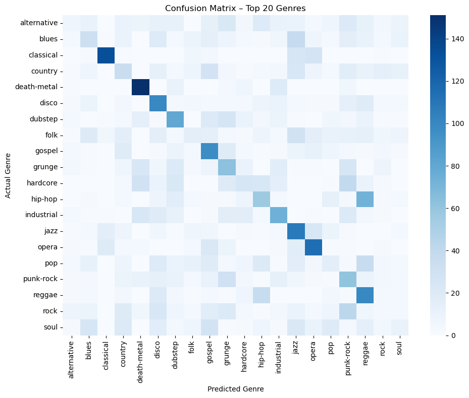

```python
cm = confusion_matrix(y_test, y_pred)
plt.figure(figsize=(10, 8))
sns.heatmap(
    cm,
    cmap="Blues",
    xticklabels=le.classes_,
    yticklabels=le.classes_)
plt.title("Confusion Matrix – Top 20 Genres")
plt.xlabel("Predicted Genre")
plt.ylabel("Actual Genre")
plt.tight_layout()
plt.show()
```

### Confusion Matrix Interpretation

The confusion matrix shows how often each genre was predicted correctly versus confused with other genres. Darker cells along the diagonal represent correct predictions, while lighter off-diagonal cells show where misclassifications occurred.

Genres with more distinctive sound profiles—such as classical, opera, death metal, and jazz—show strong diagonal patterns, meaning the model was usually able to identify them correctly. These genres tend to have clearer acoustic signatures that stand out from others.

More overlap appears among genres like rock, pop, alternative, and soul, where predictions are spread across multiple categories. This reflects how similar these styles can sound in practice and helps explain the lower precision and recall seen earlier.

Overall, the matrix highlights a clear pattern: the model performs best when genres have unique audio characteristics and struggles when styles share common musical traits. This visual breakdown adds context to the accuracy and classification report results.

```python
coef_df = pd.DataFrame(
    log_reg.coef_,
    columns=audio_features,
    index=le.classes_
)

coef_df.head()
```

|  | tempo | energy | loudness | danceability | speechiness | instrumentalness | liveness | valence | acousticness |
| --- | --- | --- | --- | --- | --- | --- | --- | --- | --- |
| alternative | -0.052169 | -0.411415 | 0.551592 | -0.011753 | 0.120193 | 0.272859 | -0.004061 | 0.021919 | -0.428471 |
| blues | -0.151853 | -0.570131 | -0.292004 | -0.308804 | 0.104301 | 0.223094 | -0.015082 | 0.917516 | 0.541828 |
| classical | -0.159973 | -0.347085 | -1.082779 | -1.098298 | 0.234557 | 1.072789 | -0.002225 | 1.102631 | 2.201897 |
| country | 0.178216 | -1.052694 | 0.593920 | -0.093165 | -1.313712 | -1.085586 | -0.086830 | 0.487462 | 0.156770 |
| death-metal | -0.412465 | 3.096129 | -1.158102 | -1.213261 | 0.415301 | 0.955276 | -0.012632 | -1.321108 | -2.843870 |

### Interpreting the Model Coefficients

The table above shows how each audio feature influences the model’s genre predictions. Each row represents a genre, and each column reflects how strongly a specific audio characteristic pushes a song toward or away from that genre.

Positive values mean that higher levels of a feature make a song more likely to be classified into that genre, while negative values mean the opposite. Because all features were scaled the same way, these values can be compared directly.

Looking at these coefficients helps explain *why* the model makes certain predictions and highlights which audio features matter most for distinguishing between genres.

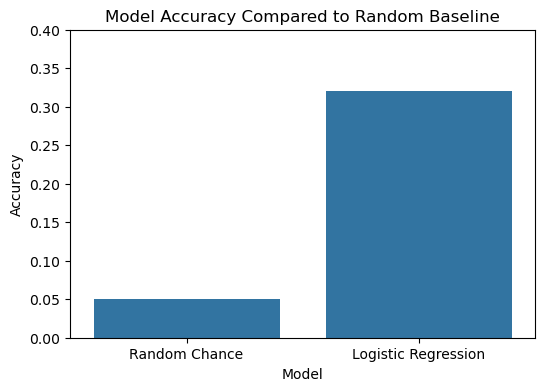

```python
accuracy_df = pd.DataFrame({
    "Model": ["Random Chance", "Logistic Regression"],
    "Accuracy": [0.05, accuracy]})
plt.figure(figsize=(6, 4))
sns.barplot(data=accuracy_df, x="Model", y="Accuracy")
plt.ylim(0, 0.4)
plt.title("Model Accuracy Compared to Random Baseline")
plt.ylabel("Accuracy")
plt.show()
```

### Model Accuracy Compared to a Random Baseline

To put the model’s performance into perspective, its accuracy was compared to what we would expect from random guessing. With 20 equally represented genres, random predictions would be correct about 5% of the time.

The chart shows that the logistic regression model reached an accuracy of about 32%, which is more than six times higher than random chance. This gap makes it clear that the Spotify audio features carry useful information for telling genres apart.

Although the accuracy is not perfect, the comparison highlights that the model is learning meaningful patterns rather than guessing. This supports the idea that features like tempo, energy, loudness, danceability, and acousticness play an important role in genre classification and provides a strong baseline for more advanced modeling approaches.

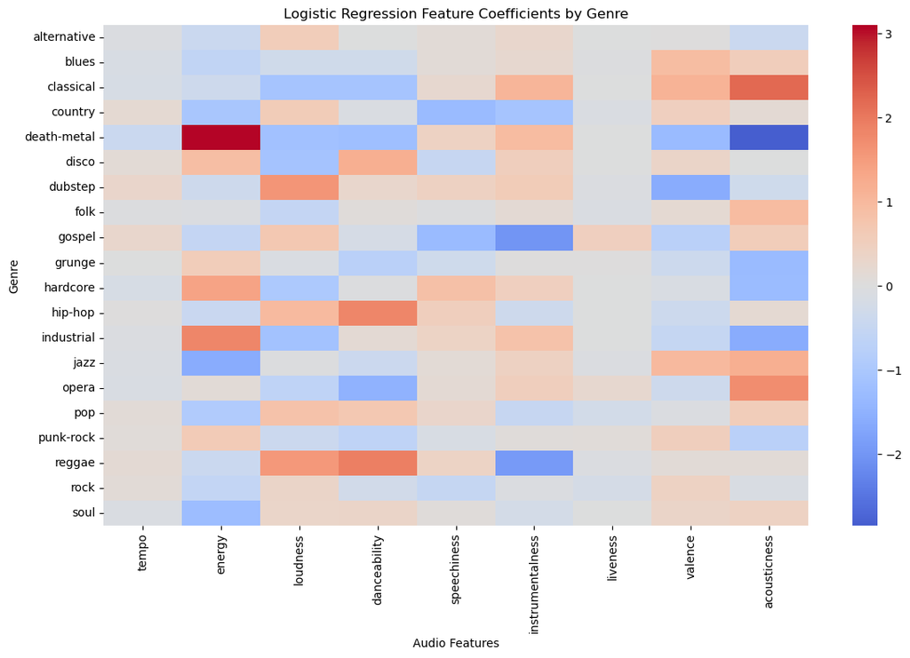

```python
coef_df = pd.DataFrame(
    log_reg.coef_,
    columns=audio_features,
    index=le.classes_)
plt.figure(figsize=(12, 8))
sns.heatmap(coef_df, cmap="coolwarm", center=0)
plt.title("Logistic Regression Feature Coefficients by Genre")
plt.xlabel("Audio Features")
plt.ylabel("Genre")
plt.tight_layout()
plt.show()
```

### Logistic Regression Coefficients by Genre

This heatmap shows how each audio feature influences the likelihood that a track belongs to a specific genre. Warmer colors indicate features that increase the probability of a genre, while cooler colors show features that make a genre less likely.

These coefficient patterns align well with real-world musical traits and provide an intuitive view of how the model uses audio features to distinguish between genres.